# Health Care Cost Prediction

Srujana Dandem

November 20, 2023

## Introduction

Kaggle Dataset: https://www.kaggle.com/datasets/teertha/ushealthinsurancedataset/data

Health insurance companies use a complex formula in order to assess how much they should charge people for health insurance. They do so by taking into account various factors like age, weight, past ailments, etc. My aim is to create a predictive model for determining which factors most influence health insurance costs and how much a person would be charged based on these factors. In order to do so, I will be looking at health insurance data that I found on Kaggle. The website link is attached above. Thus, my hypothesis is as follows:

Hypothesis: The attributes age, BMI, and number of children under the insurance plan are significant factors of influence in determining health care insurance charges.

I have chosen these particular attributes since based off of my own background knowledge on the domain, I believe they hold the greatest influence in how much a person is charged by healthcare insurance companies. I picked age since with old age, one would likely have greater ailments and hence health costs. I picked children since with the additional number of dependents being covered by the insurance policy, the insurance charge is also likely to be raised. Finally, I picked BMI since it is an overall indicator of the health of any person, and so would be relevant as well.

## Preparing the Data

```r
# Loading libraries
library(mosaic)
library(tidyverse)
library(ggplot2)
library(dplyr)
library(gridExtra)
library(reshape2)
require(mosaic)
require(mosaicData)
```

```r
# Read the dataset
insurance <- read.csv("D:/Wartburg College/Classes/Math/MA 314 Statistical Applications/Final Project/insurance.csv")
```

```r
# Shuffling the dataset
set.seed(123)
insurance = insurance[sample(1:nrow(insurance)), ]
```

We first start by taking a quick look at the data set.

```r
head(insurance)
```

|  | age | sex | bmi | children | smoker | region | charges |
| --- | --- | --- | --- | --- | --- | --- | --- |
| 415 | 19 | female | 35.150 | 0 | no | northwest | 2134.901 |
| 463 | 62 | female | 38.095 | 2 | no | northeast | 15230.324 |
| 179 | 46 | female | 28.900 | 2 | no | southwest | 8823.279 |
| 526 | 18 | female | 33.880 | 0 | no | southeast | 11482.635 |
| 195 | 18 | male | 34.430 | 0 | no | southeast | 1137.470 |
| 938 | 39 | female | 24.225 | 5 | no | northwest | 8965.796 |

Now, let us check for any missing data.

```r
# Checking for missing values
sum(is.na(insurance))
```

```
## [1] 0
```

There are no missing values in our dataset. Let us next check to see if there are any duplicate values.

```r
# Checking for duplicate values
sum(duplicated(insurance))
```

```
## [1] 1
```

We find that there is one duplicate value. This means that there are two people in our dataset with identical information. The chances of this occurring, however, is very unlikely and so must be a mistake. Hence, we will go ahead and remove one of the values.

```r
# Removing duplicate values
insurance = unique(insurance)

# Counting number of rows
nrow(insurance)
```

```
## [1] 1337
```

We see that we now have only 1337 rows after deleting the duplicate row.

## Exploratory Data Analysis (EDA)

```r
# Summary of the data
summary(insurance)
```

```
##       age            sex                 bmi           children
##  Min.   :18.00   Length:1337        Min.   :15.96   Min.   :0.000
##  1st Qu.:27.00   Class :character   1st Qu.:26.29   1st Qu.:0.000
##  Median :39.00   Mode  :character   Median :30.40   Median :1.000
##  Mean   :39.22                      Mean   :30.66   Mean   :1.096
##  3rd Qu.:51.00                      3rd Qu.:34.70   3rd Qu.:2.000
##  Max.   :64.00                      Max.   :53.13   Max.   :5.000
##     smoker             region             charges
##  Length:1337        Length:1337        Min.   : 1122
##  Class :character   Class :character   1st Qu.: 4746
##  Mode  :character   Mode  :character   Median : 9386
##                                        Mean   :13279
##                                        3rd Qu.:16658
##                                        Max.   :63770
```

From the summary, we observe that there are 7 fields in our data set. *charges* is our response variable, while age, sex, bmi, children, smoker and region are our explanatory variables. Of these, sex, smoker and region are categorical variables whilst age, bmi, children and charges are numerical variables.

Some other things for us to make note of are that the age of the people in our data, ranges from 18 yrs to 64 yrs. This assures us that there is a broad representation of ages. Also, the maximum number of children the people in the data have covered under the insurance policy is 5 children, with the average being about 1 child. The BMI ranges from 15.96 to 53.13 with the mean being 30.66. Finally, the medical costs range from 1122 USD to 63770 USD, with average costs being 13279 USD.

### Distribution of the Variables

Let us now take a look at how the various attributes are distributed by using bar charts, histograms, and box-and-whisker plots.

```r
# Sex Bar Plot
sexplot1 <- ggplot(insurance, aes(x = sex, fill = sex)) +
  geom_bar(show.legend = FALSE) +
  geom_text(
    aes(label = scales::percent(..count../sum(..count..))),
    stat = "count",
    vjust = -0.5,
    position = position_stack(vjust = 0.5)
  ) +
  labs(title = "Distribution of People by Sex", x = "Sex", y = "Count")

# Smoker Bar Plot
smokerplot1 <- ggplot(insurance, aes(x = smoker, fill = smoker)) +
  geom_bar(show.legend = FALSE) +
  geom_text(
    aes(label = scales::percent(..count../sum(..count..))),
    stat = "count",
    vjust = -0.5,
    position = position_stack(vjust = 0.5)
  ) +
  labs(title = "Distribution of People by Smoking", x = "Smoker", y = "Count")


# Region Bar Plot
regionplot1 <- ggplot(insurance, aes(x = region, fill = region)) +
  geom_bar(show.legend = FALSE) +
  geom_text(
    aes(label = scales::percent(..count../sum(..count..))),
    stat = "count",
    vjust = -0.5,
    position = position_stack(vjust = 0.5)
  ) +
  labs(title = "Distribution of People by Region", x = "Region", y = "Count")
```

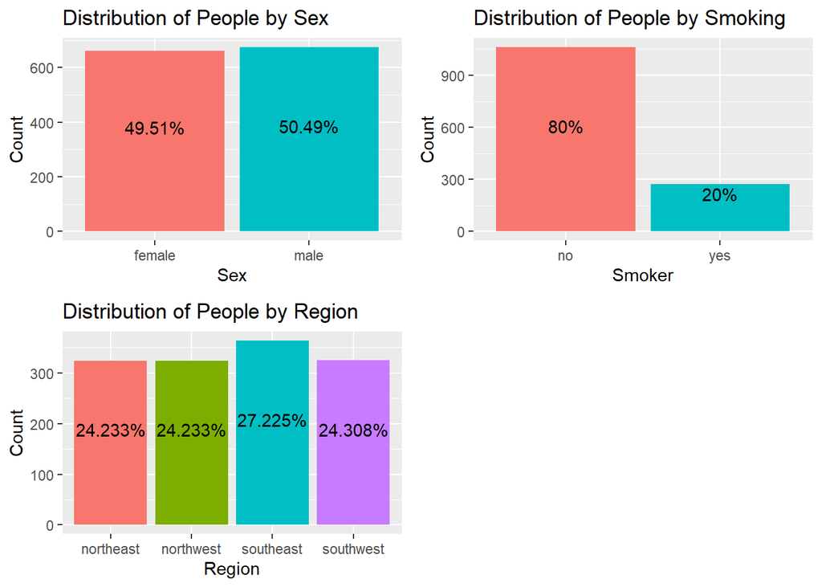

```r
# Bar Plots
grid.arrange(sexplot1, smokerplot1, regionplot1, ncol = 2, nrow = 2)
```

From the first chart “Distribution of People by Sex” given above, we observe that the proportion of Males is almost equal to the proportion of Females in our data, with there being a slightly greater number of Males at 50.49% whilst Females are 49.51%.

From the second chart “Distribution of People by Smoking”, we observe that the number of non-smokers is substantially greater than the number of smokers, with the proportion of non-smokers being at 80% and the proportion of smokers at 20%.

From the third chart “Distribution of People by Region”, we observe that the people in our data are represented in the four regions northeast, northwest, southeast, and southwest almost equally, with people from the southeast being slightly more than the rest at about 27%, and the others at around 24%.

```r
# Age Histogram
ageplot1 <- ggplot(insurance, aes(x = age)) +
geom_histogram(binwidth = 2, fill = "salmon", color = "black") +
labs(title = "Distribution of People by Age", x = "Age (years)", y = "Count")

# Age box and whisker plot
ageplot2 <- ggplot(insurance, aes(x = age, y = 1)) +
geom_boxplot(fill = "salmon", color = "black") +
labs(title = "Distribution of People by Age", x = "Age (years)", y = "")

# BMI Histogram
bmiplot1 <- ggplot(insurance, aes(x = bmi)) +
geom_histogram(binwidth = 2, fill = "lightgreen", color = "black") +
labs(title = "Distribution of People by BMI Score", x = "BMI Score", y = "Count")

# BMI box and whisker plot
bmiplot2 <- ggplot(insurance, aes(x = bmi, y = 1)) +
geom_boxplot(fill = "lightgreen", color = "black") +
labs(title = "Distribution of People by BMI Score", x = "BMI Score", y = "")

# children Histogram
childrenplot1 <- ggplot(insurance, aes(x = children)) +
geom_histogram(binwidth = 1, fill = "skyblue", color = "black") +
labs(title = "Distribution of People by Number of Children", x = "Number of Children", y = "Count")

# Children box and whisker plot
childrenplot2 <- ggplot(insurance, aes(x = children, y = 1)) +
geom_boxplot(fill = "skyblue", color = "black") +
labs(title = "Distribution of People by Number of Children", x = "Children Count", y = "")
```

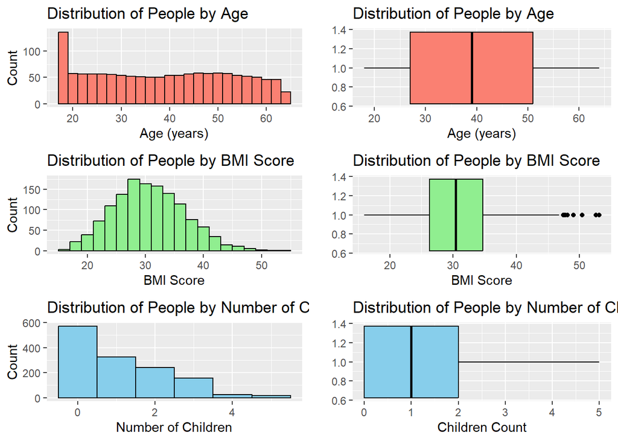

```r
# Hist and Box Plots
grid.arrange(ageplot1, ageplot2, bmiplot1, bmiplot2, childrenplot1, childrenplot2, ncol = 2, nrow = 3)
```

From the charts in the first row given above on the “Distribution of People by Age”, we observe that all ages within our data are being represented mostly equally, except for the youngest and oldest age groups which are around 18 years and 64 years respectively. We also notice from the box-and-whisker plot that there are no outliers.

From the charts in the second row on “Distribution of People by BMI Score”, we observe that the BMI scores within our dataset are fairly normally distributed. The median score of 30.40 occurs the most, whilst the lowest extreme and highest extreme scores occur the least. We have a few outliers present at the higher end of the scores.

### Distribution of the Entire Data

Let us now look at the distribution of our entire data through a histogram and box-and-whisker plot.

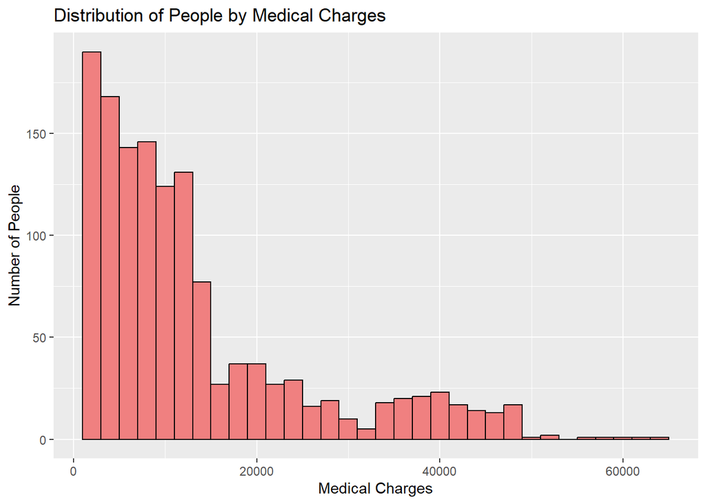

```r
# Insurance Histogram
ggplot(insurance, aes(x = charges)) +
  geom_histogram(binwidth = 2000, fill = "lightcoral", color = "black") +
  labs(title = "Distribution of People by Medical Charges", x = "Medical Charges", y = "Number of People")
```

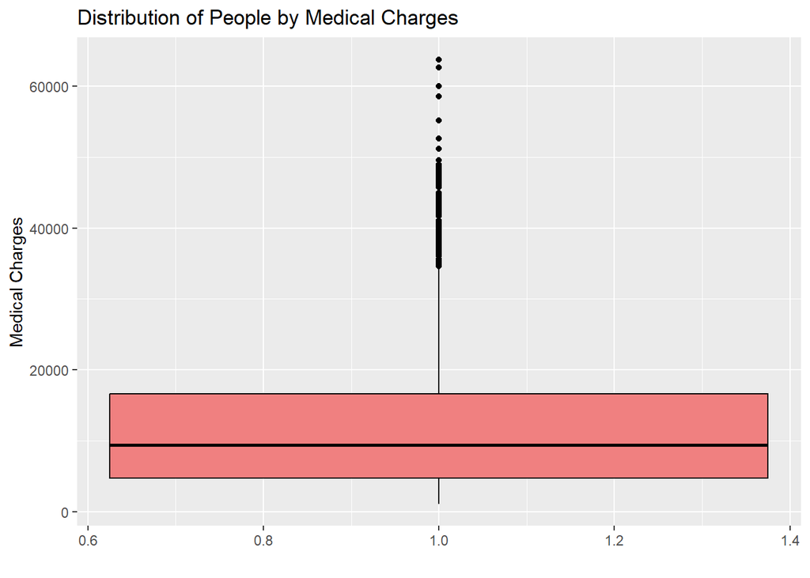

```r
#Insurance Box-and-Whisker Plot
ggplot(insurance, aes(x = 1, y = charges)) +
geom_boxplot(fill = "lightcoral", color = "black") +
labs(title = "Distribution of People by Medical Charges", x = "", y = "Medical Charges")
```

From the density plot above on “Distribution of People by Medical Charges”, we observe that our data is skewed greatly to the right. This indicates that most of the insurance charges fall on the lower end. From the box-and whisker plot above we notice that there still are some outliers towards the higher charge values, starting from around 35000 USD. Most charges, however, lie between the 4746 USD to 16658 USD range.

### Charges against Variables

We will now map out the relationship between each of the variables against charges, using box plots and scatter plots.

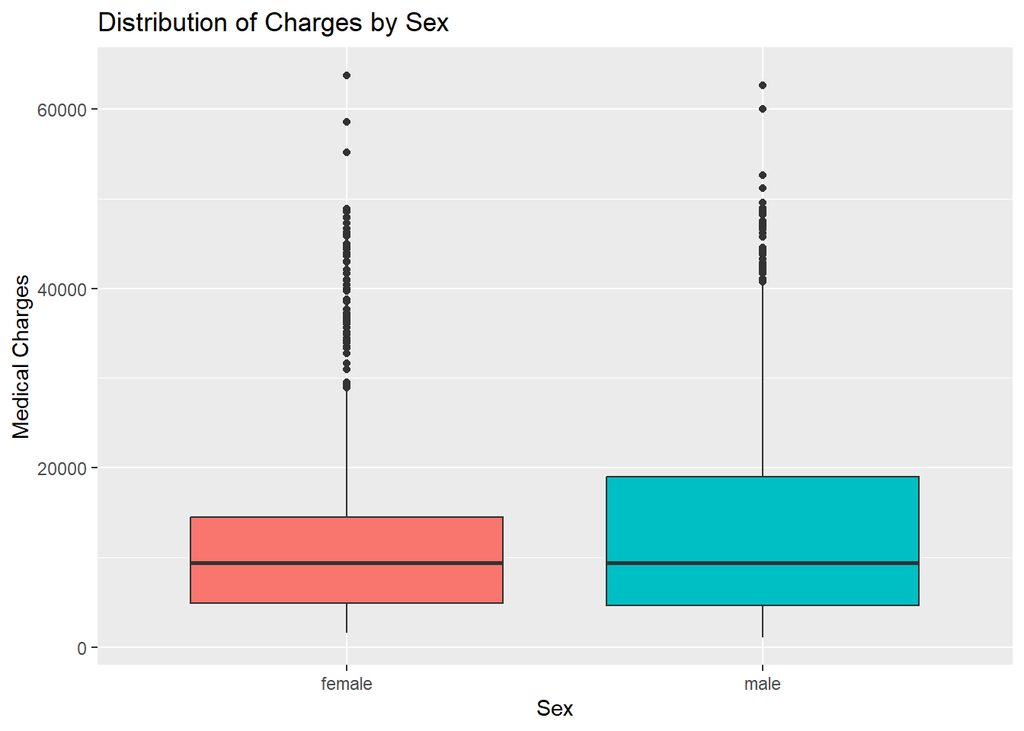

```r
# Sex vs Charges Box Plot
ggplot(insurance, aes(x = sex, y = charges, fill = sex)) +
  geom_boxplot(show.legend = FALSE) +
  labs(title = "Distribution of Charges by Sex", x = "Sex", y = "Medical Charges")
```

We notice here that the the distribution for both males and females are quite similar with the median value being about the same point as well. They also both have outliers towards the higher end points.

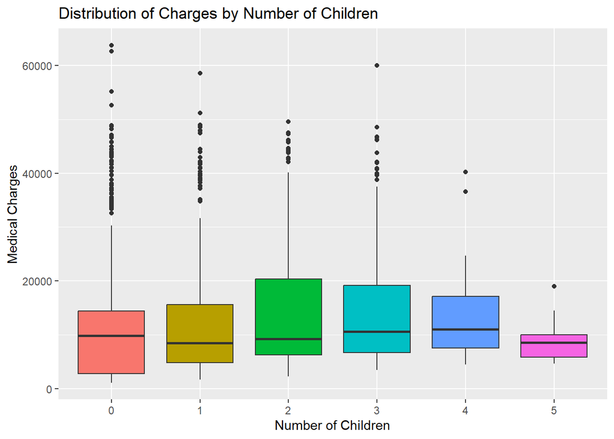

```r
# Children vs Charges Box Plot
ggplot(insurance, aes(x = as.factor(children), y = charges, fill = as.factor(children))) +
  geom_boxplot(show.legend = FALSE) +
  labs(title = "Distribution of Charges by Number of Children", x = "Number of Children", y = "Medical Charges")
```

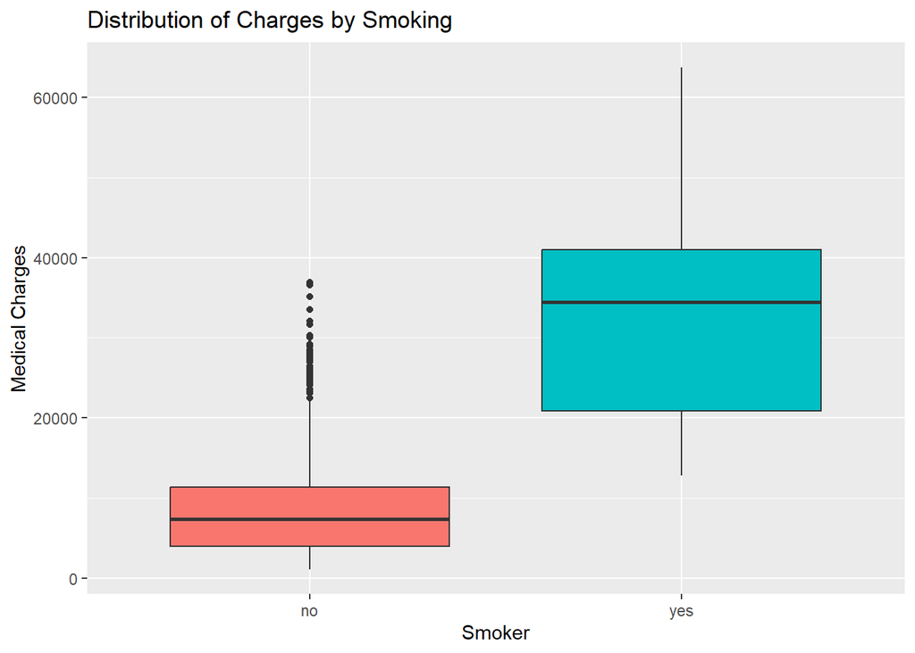

```r
# Smoker vs Charges Box Plot
ggplot(insurance, aes(x = smoker, y = charges, fill = smoker)) +
  geom_boxplot(show.legend = FALSE) +
  labs(title = "Distribution of Charges by Smoking", x = "Smoker", y = "Medical Charges")
```

We see quite a significant difference in the medians between smoker and non-smoker, with smokers (around 35000 USD) being charged much more than non-smokers (around 7000 USD). This gives us an initial sense that smoker is a crucial factor when assessing healthcare charges, and may be something that we would want to include within our model. Though the non-smokers are being charged less, we see that comparatively, they have many outliers on the higher end, whilst smokers don’t have any outliers.

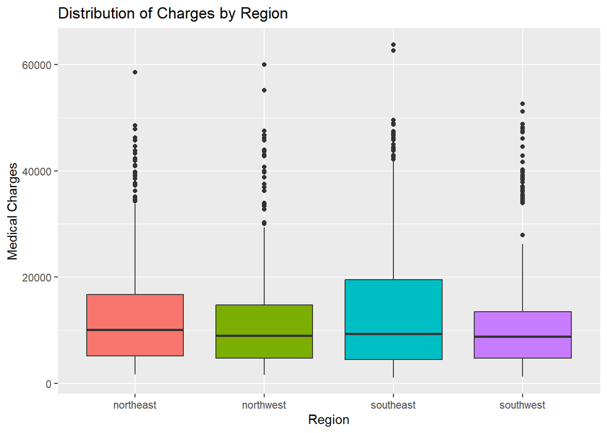

```r
# Region vs Charges Box Plot
ggplot(insurance, aes(x = region, y = charges, fill = region)) +
  geom_boxplot(show.legend = FALSE) +
  labs(title = "Distribution of Charges by Region", x = "Region", y = "Medical Charges")
```

The medians of all regions are closely situated. All of the regions also display to have outliers. Southeast shows the largest spread in its inter-quartile range while southwest shows the smallest.

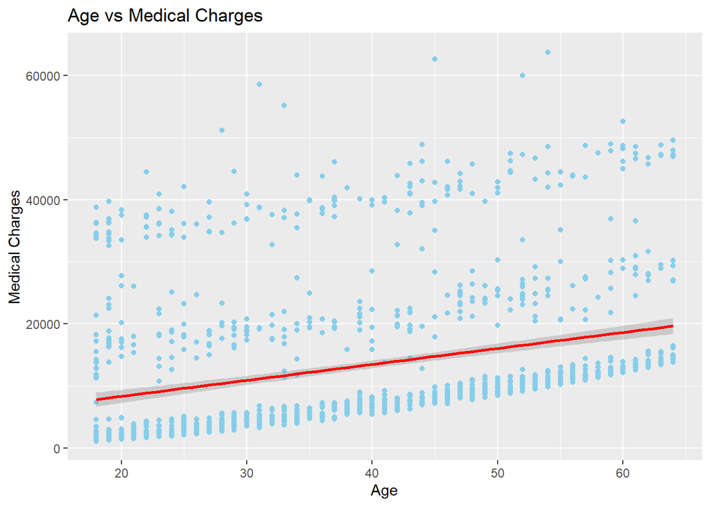

```r
# Age vs Charges Scatter plot
ggplot(insurance, aes(x = age, y = charges)) +
  geom_point(color = "skyblue") +
  geom_smooth(method = "lm", color = "red") +
  labs(title = "Age vs Medical Charges", x = "Age", y = "Medical Charges")
```

Through this scatterplot of age against charges, we observe there seem to be three different groups forming. The lowermost band is most densely packed and seems to show a positive correlation to charges. The second and third bands are more loosely packed and situated at different levels of charges, but still continue to show that positive upward slope.

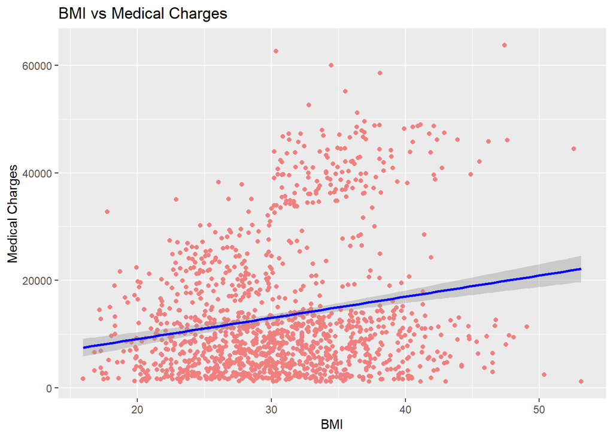

```r
# BMI vs Charges Scatter plot
ggplot(insurance, aes(x = bmi, y = charges)) +
  geom_point(color = "lightcoral") +
  geom_smooth(method = "lm", color = "blue") +
  labs(title = "BMI vs Medical Charges", x = "BMI", y = "Medical Charges")
```

We observe here too that there seems to be a positive relationship between BMI and medical charges. However, this trend is not as clearly defined as there seem to be clusters being formed at around the 25-35 BMI range.

### Correlation Heat Map

(Source:https://www.geeksforgeeks.org/how-to-create-correlation-heatmap-in-r/)

We shall now make a correlation heat map for all of our variables. In order to do so, we must first convert our categorical variables to be encoded as numeric. We do so by using the as.numeric() function.

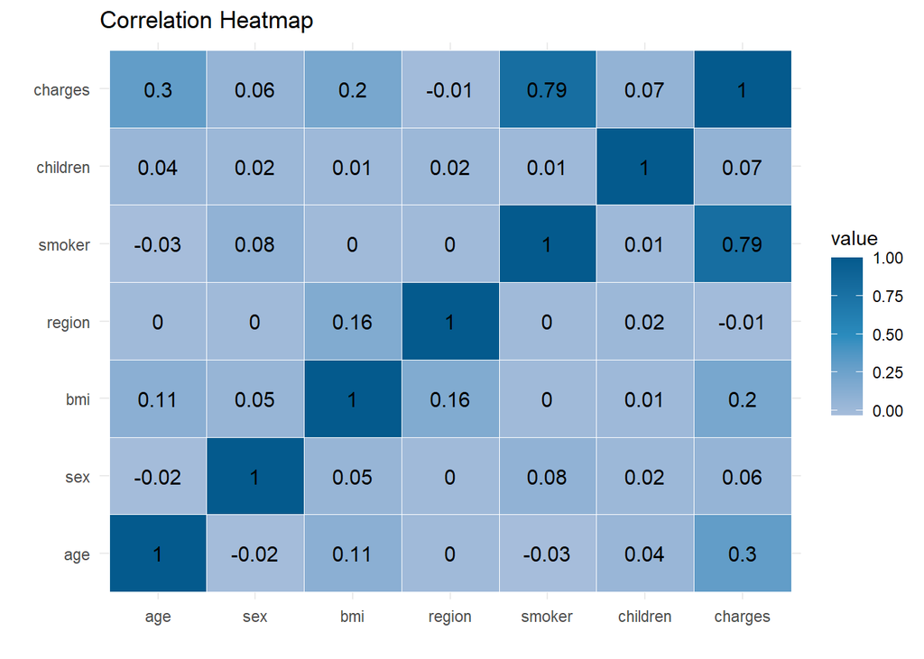

```r
# Converting categorical variables to numeric
insurance$sex <- as.numeric(factor(insurance$sex))
insurance$region <- as.numeric(factor(insurance$region))
insurance$smoker <- as.numeric(factor(insurance$smoker))

# Selecting variables
variables <- c("age", "sex", "bmi", "region", "smoker", "children", "charges")

# creating the correlation matrix
corr_mat <- round(cor(insurance[variables]), 2)

# reduce the size of correlation matrix
melted_corr_mat <- melt(corr_mat)

# plotting the correlation heatmap
ggplot(data = melted_corr_mat, aes(x = Var1, y = Var2, fill = value)) +
  geom_tile(color = "white") +
  geom_text(aes(label = value), color = "black", size = 4) +
  labs(title = "Correlation Heatmap",
       x = "", y = "") +
  theme_minimal() +
  scale_fill_gradientn(colors = c("#a6bddb", "#2b8cbe", "#045a8d"))
```

Through this correlation heatmap, we are able to see just how much of a correlation there lies between each of the variables. When independent variables are highly correlated, change in one variable would cause change to another and so the model results fluctuate significantly. We thus would want to avoid this for an accurate model. We observe that there isn’t much correlation at all between the explanatory variables. This is a good sign since it indicates that there is a low multicollinearity in our data, which is ideal. We also observe that the correlation for the response variable *charges* has the highest correlation with the explanatory variable *smoker*, at 0.79 correlation. This indicates that smoker might be a crucial factor of influence on charges. This is followed by age at 0.3 correlation, and bmi at 0.2 correlation. However, the correlation levels of age and bmi are significantly lower when compared to *smoker*.

## Splitting the Data

We shall now split 70% of our data for the training set, 15% for the validation set and 15% for the test set.

```r
set.seed(123)

sample_train <- sample(1:nrow(insurance), size = 0.7 * nrow(insurance), replace = FALSE)

training <- insurance[sample_train, ]

remaining <- insurance[-sample_train, ]

sample_validation <- sample(1:nrow(remaining), size = 0.5 * nrow(remaining), replace = FALSE)

validation <- remaining[sample_validation, ]

test <- remaining[-sample_validation, ]
```

We verify the partitions by checking the dimensions of each set:

```r
print(dim(training))
```

```
## [1] 935   7
```

```r
print(dim(validation))
```

```
## [1] 201   7
```

```r
print(dim(test))
```

```
## [1] 201   7
```

## Building the Model

### Models with One Explanatory Variable

We first try building all possible variations of models that use *charges* as a response variable and only one explanatory variable.

```r
mod1 <- lm(charges ~ age, data = training)
summary(mod1)
```

```
##
## Call:
## lm(formula = charges ~ age, data = training)
##
## Residuals:
##    Min     1Q Median     3Q    Max
##  -8289  -6873  -6156   5330  47544
##
## Coefficients:
##             Estimate Std. Error t value Pr(>|t|)
## (Intercept)  2951.28    1170.00   2.522   0.0118 *
## age           268.84      28.06   9.580   <2e-16 ***
## ---
## Signif. codes:  0 '***' 0.001 '**' 0.01 '*' 0.05 '.' 0.1 ' ' 1
##
## Residual standard error: 11880 on 933 degrees of freedom
## Multiple R-squared:  0.08957,    Adjusted R-squared:  0.08859
## F-statistic: 91.79 on 1 and 933 DF,  p-value: < 2.2e-16
```

```r
confint(mod1)
```

```
##                2.5 %   97.5 %
## (Intercept) 655.1505 5247.416
## age         213.7717  323.914
```

```r
mod2 <- lm(charges ~ bmi, data = training)
summary(mod2)
```

```
##
## Call:
## lm(formula = charges ~ bmi, data = training)
##
## Residuals:
##    Min     1Q Median     3Q    Max
## -22571  -8334  -4048   4706  49206
##
## Coefficients:
##             Estimate Std. Error t value Pr(>|t|)
## (Intercept)  -408.68    2019.71  -0.202     0.84
## bmi           454.41      64.59   7.036 3.84e-12 ***
## ---
## Signif. codes:  0 '***' 0.001 '**' 0.01 '*' 0.05 '.' 0.1 ' ' 1
##
## Residual standard error: 12130 on 933 degrees of freedom
## Multiple R-squared:  0.05038,    Adjusted R-squared:  0.04936
## F-statistic:  49.5 on 1 and 933 DF,  p-value: 3.839e-12
```

```r
confint(mod2)
```

```
##                  2.5 %    97.5 %
## (Intercept) -4372.3815 3555.0289
## bmi           327.6586  581.1676
```

```r
mod3 <- lm(charges ~ children, data = training)
summary(mod3)
```

```
##
## Call:
## lm(formula = charges ~ children, data = training)
##
## Residuals:
##    Min     1Q Median     3Q    Max
## -11889  -8850  -4189   3366  50759
##
## Coefficients:
##             Estimate Std. Error t value Pr(>|t|)
## (Intercept)  13011.2      553.6  23.502   <2e-16 ***
## children       467.9      342.5   1.366    0.172
## ---
## Signif. codes:  0 '***' 0.001 '**' 0.01 '*' 0.05 '.' 0.1 ' ' 1
##
## Residual standard error: 12440 on 933 degrees of freedom
## Multiple R-squared:  0.001997,   Adjusted R-squared:  0.0009272
## F-statistic: 1.867 on 1 and 933 DF,  p-value: 0.1722
```

```r
confint(mod3)
```

```
##                  2.5 %    97.5 %
## (Intercept) 11924.6832 14097.618
## children     -204.1952  1140.088
```

```r
mod4 <- lm(charges ~ sex , data = training)
summary(mod4)
```

```
##
## Call:
## lm(formula = charges ~ sex, data = training)
##
## Residuals:
##    Min     1Q Median     3Q    Max
## -12578  -8781  -4079   3467  50428
##
## Coefficients:
##             Estimate Std. Error t value Pr(>|t|)
## (Intercept)  12986.1     1294.0  10.035   <2e-16 ***
## sex            356.8      814.5   0.438    0.661
## ---
## Signif. codes:  0 '***' 0.001 '**' 0.01 '*' 0.05 '.' 0.1 ' ' 1
##
## Residual standard error: 12450 on 933 degrees of freedom
## Multiple R-squared:  0.0002056,  Adjusted R-squared:  -0.000866
## F-statistic: 0.1918 on 1 and 933 DF,  p-value: 0.6615
```

```r
confint(mod4)
```

```
##                 2.5 %    97.5 %
## (Intercept) 10446.588 15525.706
## sex         -1241.729  1955.238
```

```r
mod5 <- lm(charges ~ smoker, data = training)
summary(mod5)
```

```
##
## Call:
## lm(formula = charges ~ smoker, data = training)
##
## Residuals:
##      Min       1Q   Median       3Q      Max
## -19797.6  -4904.6   -767.4   3744.1  31143.4
##
## Coefficients:
##             Estimate Std. Error t value Pr(>|t|)
## (Intercept) -15843.0      771.6  -20.53   <2e-16 ***
## smoker       24235.0      603.4   40.17   <2e-16 ***
## ---
## Signif. codes:  0 '***' 0.001 '**' 0.01 '*' 0.05 '.' 0.1 ' ' 1
##
## Residual standard error: 7538 on 933 degrees of freedom
## Multiple R-squared:  0.6336, Adjusted R-squared:  0.6332
## F-statistic:  1613 on 1 and 933 DF,  p-value: < 2.2e-16
```

```r
confint(mod5)
```

```
##                 2.5 %    97.5 %
## (Intercept) -17357.28 -14328.79
## smoker       23050.92  25419.17
```

```r
mod6 <- lm(charges ~ region, data = training)
summary(mod6)
```

```
##
## Call:
## lm(formula = charges ~ region, data = training)
##
## Residuals:
##    Min     1Q Median     3Q    Max
## -12309  -8800  -4096   3481  50340
##
## Coefficients:
##             Estimate Std. Error t value Pr(>|t|)
## (Intercept)  14002.0     1009.9  13.865   <2e-16 ***
## region        -190.4      368.2  -0.517    0.605
## ---
## Signif. codes:  0 '***' 0.001 '**' 0.01 '*' 0.05 '.' 0.1 ' ' 1
##
## Residual standard error: 12450 on 933 degrees of freedom
## Multiple R-squared:  0.0002865,  Adjusted R-squared:  -0.000785
## F-statistic: 0.2674 on 1 and 933 DF,  p-value: 0.6052
```

```r
confint(mod6)
```

```
##                  2.5 %     97.5 %
## (Intercept) 12020.1091 15983.9803
## region       -912.9303   532.1543
```

After our trials, we find that mod5 has the best fit out of the above models. This is because it has the highest Adjusted R^2 values at 0.633.

$R^2$ is the proportion of the total variation in the response variable that is accounted for by the model. The value of R^2 lies between zero and one. When R^2 = 0, the model accounts for none of the variance of the response values: the model is useless. When R² = 1, the model captures all of the variance of the response values: the model values are exactly on target.

Over here, having an R^2 value of 0.633 indicates that 63.3% of the variance in our response value is being accounted for by our model. This is a considerably good fit, but still not the best.

The second highest adjusted R^2 occurs with mod1 at 0.088, which is considerably lesser. Though, mod5 has a relatively larger Standard Error and thus larger confidence interval when compared to the rest of the models, upon taking into consideration the massive difference in Adjusted R^2, we shall choose mod5 as the best model. Moreover, smoker is also a statistically significant variable, given how its p-value < 0.05.

Thus, we shall continue with our experimentation for model building, holding the first explanatory term fixed as *smoker*.

### Models with Two Explanatory Variable

Next, we try building all combinations of models that use charges for a response variable, and two explanatory variables. The first explanatory variable is fixed as *smoker*, as decided from the previous models.

```r
mod8 <- lm(charges ~ smoker + age, data = training)
summary(mod8)
```

```
##
## Call:
## lm(formula = charges ~ smoker + age, data = training)
##
## Residuals:
##      Min       1Q   Median       3Q      Max
## -15783.1  -1992.7  -1276.2   -110.6  28216.7
##
## Coefficients:
##              Estimate Std. Error t value Pr(>|t|)
## (Intercept) -27184.64     898.74  -30.25   <2e-16 ***
## smoker       24419.45     515.82   47.34   <2e-16 ***
## age            282.71      15.22   18.58   <2e-16 ***
## ---
## Signif. codes:  0 '***' 0.001 '**' 0.01 '*' 0.05 '.' 0.1 ' ' 1
##
## Residual standard error: 6443 on 932 degrees of freedom
## Multiple R-squared:  0.7326, Adjusted R-squared:  0.732
## F-statistic:  1277 on 2 and 932 DF,  p-value: < 2.2e-16
```

```r
confint(mod8)
```

```
##                   2.5 %      97.5 %
## (Intercept) -28948.4162 -25420.8550
## smoker       23407.1357  25431.7582
## age            252.8408    312.5761
```

```r
mod9 <- lm(charges ~ smoker + bmi, data = training)
summary(mod9)
```

```
##
## Call:
## lm(formula = charges ~ smoker + bmi, data = training)
##
## Residuals:
##      Min       1Q   Median       3Q      Max
## -17161.1  -4310.3   -523.2   3620.1  30140.6
##
## Coefficients:
##              Estimate Std. Error t value Pr(>|t|)
## (Intercept) -29317.42    1350.70  -21.70   <2e-16 ***
## smoker       24181.96     563.17   42.94   <2e-16 ***
## bmi            441.56      37.45   11.79   <2e-16 ***
## ---
## Signif. codes:  0 '***' 0.001 '**' 0.01 '*' 0.05 '.' 0.1 ' ' 1
##
## Residual standard error: 7035 on 932 degrees of freedom
## Multiple R-squared:  0.6812, Adjusted R-squared:  0.6805
## F-statistic: 995.5 on 2 and 932 DF,  p-value: < 2.2e-16
```

```r
confint(mod9)
```

```
##                 2.5 %      97.5 %
## (Intercept) -31968.19 -26666.6601
## smoker       23076.74  25287.1850
## bmi            368.07    515.0495
```

```r
mod10 <- lm(charges ~ smoker + children , data = training)
summary(mod10)
```

```
##
## Call:
## lm(formula = charges ~ smoker + children, data = training)
##
## Residuals:
##    Min     1Q Median     3Q    Max
## -20299  -4856   -979   4009  31727
##
## Coefficients:
##             Estimate Std. Error t value Pr(>|t|)
## (Intercept) -16454.9      803.8 -20.472  < 2e-16 ***
## smoker       24249.2      601.5  40.314  < 2e-16 ***
## children       542.5      206.9   2.622  0.00887 **
## ---
## Signif. codes:  0 '***' 0.001 '**' 0.01 '*' 0.05 '.' 0.1 ' ' 1
##
## Residual standard error: 7514 on 932 degrees of freedom
## Multiple R-squared:  0.6363, Adjusted R-squared:  0.6355
## F-statistic: 815.2 on 2 and 932 DF,  p-value: < 2.2e-16
```

```r
confint(mod10)
```

```
##                   2.5 %      97.5 %
## (Intercept) -18032.3194 -14877.4809
## smoker       23068.6905  25429.6188
## children       136.5381    948.5558
```

```r
mod11 <- lm(charges ~ smoker + region, data = training)
summary(mod11)
```

```
##
## Call:
## lm(formula = charges ~ smoker + region, data = training)
##
## Residuals:
##      Min       1Q   Median       3Q      Max
## -19954.6  -4861.6   -794.5   3777.3  31197.1
##
## Coefficients:
##             Estimate Std. Error t value Pr(>|t|)
## (Intercept) -15575.2      957.6 -16.265   <2e-16 ***
## smoker       24232.3      603.7  40.143   <2e-16 ***
## region        -105.4      223.0  -0.473    0.637
## ---
## Signif. codes:  0 '***' 0.001 '**' 0.01 '*' 0.05 '.' 0.1 ' ' 1
##
## Residual standard error: 7541 on 932 degrees of freedom
## Multiple R-squared:  0.6337, Adjusted R-squared:  0.6329
## F-statistic: 806.1 on 2 and 932 DF,  p-value: < 2.2e-16
```

```r
confint(mod11)
```

```
##                   2.5 %      97.5 %
## (Intercept) -17454.5186 -13695.9156
## smoker       23047.6604  25417.0119
## region        -543.0204    332.2512
```

```r
mod12 <- lm(charges ~ smoker + sex, data = training)
summary(mod12)
```

```
##
## Call:
## lm(formula = charges ~ smoker + sex, data = training)
##
## Residuals:
##      Min       1Q   Median       3Q      Max
## -19610.1  -4906.4   -914.8   3755.7  30918.4
##
## Coefficients:
##             Estimate Std. Error t value Pr(>|t|)
## (Intercept) -15244.7     1052.6 -14.483   <2e-16 ***
## smoker       24254.6      603.9  40.162   <2e-16 ***
## sex           -412.5      493.5  -0.836    0.403
## ---
## Signif. codes:  0 '***' 0.001 '**' 0.01 '*' 0.05 '.' 0.1 ' ' 1
##
## Residual standard error: 7539 on 932 degrees of freedom
## Multiple R-squared:  0.6339, Adjusted R-squared:  0.6331
## F-statistic: 806.7 on 2 and 932 DF,  p-value: < 2.2e-16
```

```r
confint(mod12)
```

```
##                  2.5 %      97.5 %
## (Intercept) -17310.475 -13178.9135
## smoker       23069.422  25439.8485
## sex          -1381.095    556.0722
```

We find that the mod8 has the best fit out of the above models with an adjusted R^2 value of 0.732 and a relatively low confidence interval.

Age too is a statistically significant variable. Hence, we shall continue by holding the first two explanatory terms fixed as *smoker* and *age*.

### Models with Three Explanatory Variables

Next, we try building all combinations of models that use charges for a response variable, and three explanatory variables. The first two explanatory variables are fixed as *smoker* and *age* as decided from the previous models.

```r
mod13 <- lm(charges ~ smoker + age + bmi, data = training)
summary(mod13)
```

```
##
## Call:
## lm(formula = charges ~ smoker + age + bmi, data = training)
##
## Residuals:
##      Min       1Q   Median       3Q      Max
## -11862.3  -3001.1   -838.1   1862.0  28501.3
##
## Coefficients:
##              Estimate Std. Error t value Pr(>|t|)
## (Intercept) -37095.24    1244.22  -29.81   <2e-16 ***
## smoker       24361.56     486.18   50.11   <2e-16 ***
## age            259.45      14.50   17.89   <2e-16 ***
## bmi            355.35      32.68   10.87   <2e-16 ***
## ---
## Signif. codes:  0 '***' 0.001 '**' 0.01 '*' 0.05 '.' 0.1 ' ' 1
##
## Residual standard error: 6072 on 931 degrees of freedom
## Multiple R-squared:  0.7627, Adjusted R-squared:  0.762
## F-statistic: 997.6 on 3 and 931 DF,  p-value: < 2.2e-16
```

```r
confint(mod13)
```

```
##                   2.5 %      97.5 %
## (Intercept) -39537.0523 -34653.4346
## smoker       23407.4245  25315.6932
## age            230.9925    287.9138
## bmi            291.2155    419.4775
```

```r
mod14 <- lm(charges ~ smoker + age + children, data = training)
summary(mod14)
```

```
##
## Call:
## lm(formula = charges ~ smoker + age + children, data = training)
##
## Residuals:
##      Min       1Q   Median       3Q      Max
## -15745.6  -1889.6  -1261.6   -346.6  28740.3
##
## Coefficients:
##              Estimate Std. Error t value Pr(>|t|)
## (Intercept) -27698.12     915.21 -30.264   <2e-16 ***
## smoker       24431.49     514.07  47.526   <2e-16 ***
## age            281.95      15.17  18.587   <2e-16 ***
## children       482.30     176.81   2.728   0.0065 **
## ---
## Signif. codes:  0 '***' 0.001 '**' 0.01 '*' 0.05 '.' 0.1 ' ' 1
##
## Residual standard error: 6421 on 931 degrees of freedom
## Multiple R-squared:  0.7347, Adjusted R-squared:  0.7339
## F-statistic: 859.5 on 3 and 931 DF,  p-value: < 2.2e-16
```

```r
confint(mod14)
```

```
##                   2.5 %      97.5 %
## (Intercept) -29494.2457 -25902.0022
## smoker       23422.6251  25440.3648
## age            252.1798    311.7199
## children       135.3131    829.2847
```

```r
mod15 <- lm(charges ~ smoker + age + sex, data = training)
summary(mod15)
```

```
##
## Call:
## lm(formula = charges ~ smoker + age + sex, data = training)
##
## Residuals:
##    Min     1Q Median     3Q    Max
## -15688  -1991  -1257   -150  28313
##
## Coefficients:
##              Estimate Std. Error t value Pr(>|t|)
## (Intercept) -26874.56    1096.81 -24.503   <2e-16 ***
## smoker       24429.21     516.41  47.306   <2e-16 ***
## age            282.51      15.23  18.549   <2e-16 ***
## sex           -208.36     422.10  -0.494    0.622
## ---
## Signif. codes:  0 '***' 0.001 '**' 0.01 '*' 0.05 '.' 0.1 ' ' 1
##
## Residual standard error: 6446 on 931 degrees of freedom
## Multiple R-squared:  0.7327, Adjusted R-squared:  0.7318
## F-statistic: 850.5 on 3 and 931 DF,  p-value: < 2.2e-16
```

```r
confint(mod15)
```

```
##                   2.5 %      97.5 %
## (Intercept) -29027.0566 -24722.0560
## smoker       23415.7460  25442.6817
## age            252.6224    312.4024
## sex          -1036.7292    620.0176
```

```r
mod16 <- lm(charges ~ smoker + age + region, data = training)
summary(mod16)
```

```
##
## Call:
## lm(formula = charges ~ smoker + age + region, data = training)
##
## Residuals:
##      Min       1Q   Median       3Q      Max
## -15704.9  -1986.5  -1220.3   -174.8  28294.1
##
## Coefficients:
##              Estimate Std. Error t value Pr(>|t|)
## (Intercept) -26800.78    1017.15 -26.349   <2e-16 ***
## smoker       24415.61     515.94  47.322   <2e-16 ***
## age            282.88      15.22  18.582   <2e-16 ***
## region        -153.69     190.58  -0.806     0.42
## ---
## Signif. codes:  0 '***' 0.001 '**' 0.01 '*' 0.05 '.' 0.1 ' ' 1
##
## Residual standard error: 6444 on 931 degrees of freedom
## Multiple R-squared:  0.7328, Adjusted R-squared:  0.7319
## F-statistic:   851 on 3 and 931 DF,  p-value: < 2.2e-16
```

```r
confint(mod16)
```

```
##                   2.5 %      97.5 %
## (Intercept) -28796.9575 -24804.6080
## smoker       23403.0599  25428.1514
## age            252.9998    312.7520
## region        -527.7038    220.3261
```

We find that the mod13 has the best fit out of the above models with an adjusted R^2 value of 0.762 and a low confidence interval.

BMI too is a statistically significant variable. Hence, we shall continue by holding the first three explanatory terms fixed as *smoker*, *age* and *bmi*.

### Models with Four Explanatory Variables

Next, we try building all combinations of models that use charges for a response variable, and four explanatory variables. The first three explanatory variables are fixed as *smoker*, *age*, and *bmi* as decided from the previous models.

```r
mod17 <- lm(charges ~ smoker + age + bmi + children, data = training)
summary(mod17)
```

```
##
## Call:
## lm(formula = charges ~ smoker + age + bmi + children, data = training)
##
## Residuals:
##      Min       1Q   Median       3Q      Max
## -11843.3  -2923.6   -818.1   1694.1  28991.2
##
## Coefficients:
##              Estimate Std. Error t value Pr(>|t|)
## (Intercept) -37536.22    1250.59 -30.015  < 2e-16 ***
## smoker       24373.10     484.54  50.301  < 2e-16 ***
## age            258.84      14.45  17.907  < 2e-16 ***
## bmi            353.89      32.57  10.865  < 2e-16 ***
## children       452.42     166.66   2.715  0.00676 **
## ---
## Signif. codes:  0 '***' 0.001 '**' 0.01 '*' 0.05 '.' 0.1 ' ' 1
##
## Residual standard error: 6052 on 930 degrees of freedom
## Multiple R-squared:  0.7646, Adjusted R-squared:  0.7636
## F-statistic: 755.2 on 4 and 930 DF,  p-value: < 2.2e-16
```

```r
confint(mod17)
```

```
##                   2.5 %      97.5 %
## (Intercept) -39990.5191 -35081.9233
## smoker       23422.1726  25324.0235
## age            230.4696    287.2044
## bmi            289.9659    417.8089
## children       125.3342    779.4964
```

```r
mod18 <- lm(charges ~ smoker + age + bmi + sex, data = training)
summary(mod18)
```

```
##
## Call:
## lm(formula = charges ~ smoker + age + bmi + sex, data = training)
##
## Residuals:
##      Min       1Q   Median       3Q      Max
## -11643.4  -3056.6   -847.4   1869.2  28703.2
##
## Coefficients:
##              Estimate Std. Error t value Pr(>|t|)
## (Intercept) -36499.56    1358.20 -26.874   <2e-16 ***
## smoker       24381.66     486.48  50.119   <2e-16 ***
## age            258.92      14.51  17.846   <2e-16 ***
## bmi            357.21      32.72  10.918   <2e-16 ***
## sex           -435.26     398.16  -1.093    0.275
## ---
## Signif. codes:  0 '***' 0.001 '**' 0.01 '*' 0.05 '.' 0.1 ' ' 1
##
## Residual standard error: 6072 on 930 degrees of freedom
## Multiple R-squared:  0.763,  Adjusted R-squared:  0.762
## F-statistic: 748.6 on 4 and 930 DF,  p-value: < 2.2e-16
```

```r
confint(mod18)
```

```
##                   2.5 %      97.5 %
## (Intercept) -39165.0392 -33834.0717
## smoker       23426.9401  25336.3757
## age            230.4477    287.3952
## bmi            293.0017    421.4254
## sex          -1216.6454    346.1289
```

```r
mod19 <- lm(charges ~ smoker + age + bmi + region, data = training)
summary(mod19)
```

```
##
## Call:
## lm(formula = charges ~ smoker + age + bmi + region, data = training)
##
## Residuals:
##      Min       1Q   Median       3Q      Max
## -11651.6  -3047.0   -845.1   1781.1  28715.5
##
## Coefficients:
##              Estimate Std. Error t value Pr(>|t|)
## (Intercept) -36336.87    1285.56 -28.265   <2e-16 ***
## smoker       24349.74     485.12  50.193   <2e-16 ***
## age            259.27      14.47  17.918   <2e-16 ***
## bmi            364.91      32.88  11.100   <2e-16 ***
## region        -410.39     180.67  -2.271   0.0233 *
## ---
## Signif. codes:  0 '***' 0.001 '**' 0.01 '*' 0.05 '.' 0.1 ' ' 1
##
## Residual standard error: 6059 on 930 degrees of freedom
## Multiple R-squared:  0.764,  Adjusted R-squared:  0.763
## F-statistic: 752.8 on 4 and 930 DF,  p-value: < 2.2e-16
```

```r
confint(mod19)
```

```
##                   2.5 %       97.5 %
## (Intercept) -38859.8110 -33813.92425
## smoker       23397.6784  25301.81041
## age            230.8769    287.67247
## bmi            300.3865    429.42456
## region        -764.9507    -55.81974
```

We find that the mod17 has the best fit out of the above models with an adjusted R^2 value of 0.7636 and a low confidence interval.

However, we notice that compared to mod13 which has an R^2 of 0.762, mod17 isn’t really adding a whole lot more to the model. Thus, we are inclined to continue with mod13 since it is always best to choose the model which explains the most using the least number of terms.

### Initial Models Selection

We now experiment further on mod13 by switching up the order of its explanatory variables, and conducting ANOVA tests to further narrow down on the best model form.

```r
mod20 <- lm(charges ~ smoker + age + bmi, data = training)
summary(mod20)
```

```
##
## Call:
## lm(formula = charges ~ smoker + age + bmi, data = training)
##
## Residuals:
##      Min       1Q   Median       3Q      Max
## -11862.3  -3001.1   -838.1   1862.0  28501.3
##
## Coefficients:
##              Estimate Std. Error t value Pr(>|t|)
## (Intercept) -37095.24    1244.22  -29.81   <2e-16 ***
## smoker       24361.56     486.18   50.11   <2e-16 ***
## age            259.45      14.50   17.89   <2e-16 ***
## bmi            355.35      32.68   10.87   <2e-16 ***
## ---
## Signif. codes:  0 '***' 0.001 '**' 0.01 '*' 0.05 '.' 0.1 ' ' 1
##
## Residual standard error: 6072 on 931 degrees of freedom
## Multiple R-squared:  0.7627, Adjusted R-squared:  0.762
## F-statistic: 997.6 on 3 and 931 DF,  p-value: < 2.2e-16
```

```r
anova(mod20)
```

|  | Df | Sum Sq | Mean Sq | F value | Pr(>F) |
| --- | --- | --- | --- | --- | --- |
| smoker | 1 | 91666094537 | 91666094537 | 2486.0375 | 4.153019e-265 |
| age | 1 | 14323946753 | 14323946753 | 388.4737 | 1.518059e-72 |
| bmi | 1 | 4360093139 | 4360093139 | 118.2482 | 5.188589e-26 |
| Residuals | 931 | 34328176045 | 36872370 | NA | NA |

```r
confint(mod20)
```

```
##                   2.5 %      97.5 %
## (Intercept) -39537.0523 -34653.4346
## smoker       23407.4245  25315.6932
## age            230.9925    287.9138
## bmi            291.2155    419.4775
```

```r
mod21 <- lm(charges ~ smoker + bmi + age, data = training)
summary(mod21)
```

```
##
## Call:
## lm(formula = charges ~ smoker + bmi + age, data = training)
##
## Residuals:
##      Min       1Q   Median       3Q      Max
## -11862.3  -3001.1   -838.1   1862.0  28501.3
##
## Coefficients:
##              Estimate Std. Error t value Pr(>|t|)
## (Intercept) -37095.24    1244.22  -29.81   <2e-16 ***
## smoker       24361.56     486.18   50.11   <2e-16 ***
## bmi            355.35      32.68   10.87   <2e-16 ***
## age            259.45      14.50   17.89   <2e-16 ***
## ---
## Signif. codes:  0 '***' 0.001 '**' 0.01 '*' 0.05 '.' 0.1 ' ' 1
##
## Residual standard error: 6072 on 931 degrees of freedom
## Multiple R-squared:  0.7627, Adjusted R-squared:  0.762
## F-statistic: 997.6 on 3 and 931 DF,  p-value: < 2.2e-16
```

```r
anova(mod21)
```

|  | Df | Sum Sq | Mean Sq | F value | Pr(>F) |
| --- | --- | --- | --- | --- | --- |
| smoker | 1 | 91666094537 | 91666094537 | 2486.0375 | 4.153019e-265 |
| bmi | 1 | 6882070455 | 6882070455 | 186.6457 | 7.314554e-39 |
| age | 1 | 11801969437 | 11801969437 | 320.0762 | 9.386393e-62 |
| Residuals | 931 | 34328176045 | 36872370 | NA | NA |

```r
confint(mod21)
```

```
##                   2.5 %      97.5 %
## (Intercept) -39537.0523 -34653.4346
## smoker       23407.4245  25315.6932
## bmi            291.2155    419.4775
## age            230.9925    287.9138
```

```r
mod22 <- lm(charges ~ age + smoker + bmi, data = training)
summary(mod22)
```

```
##
## Call:
## lm(formula = charges ~ age + smoker + bmi, data = training)
##
## Residuals:
##      Min       1Q   Median       3Q      Max
## -11862.3  -3001.1   -838.1   1862.0  28501.3
##
## Coefficients:
##              Estimate Std. Error t value Pr(>|t|)
## (Intercept) -37095.24    1244.22  -29.81   <2e-16 ***
## age            259.45      14.50   17.89   <2e-16 ***
## smoker       24361.56     486.18   50.11   <2e-16 ***
## bmi            355.35      32.68   10.87   <2e-16 ***
## ---
## Signif. codes:  0 '***' 0.001 '**' 0.01 '*' 0.05 '.' 0.1 ' ' 1
##
## Residual standard error: 6072 on 931 degrees of freedom
## Multiple R-squared:  0.7627, Adjusted R-squared:  0.762
## F-statistic: 997.6 on 3 and 931 DF,  p-value: < 2.2e-16
```

```r
anova(mod22)
```

|  | Df | Sum Sq | Mean Sq | F value | Pr(>F) |
| --- | --- | --- | --- | --- | --- |
| age | 1 | 12958152540 | 12958152540 | 351.4326 | 8.978726e-67 |
| smoker | 1 | 93031888750 | 93031888750 | 2523.0787 | 2.740338e-267 |
| bmi | 1 | 4360093139 | 4360093139 | 118.2482 | 5.188589e-26 |
| Residuals | 931 | 34328176045 | 36872370 | NA | NA |

```r
confint(mod22)
```

```
##                   2.5 %      97.5 %
## (Intercept) -39537.0523 -34653.4346
## age            230.9925    287.9138
## smoker       23407.4245  25315.6932
## bmi            291.2155    419.4775
```

```r
mod23 <- lm(charges ~ age + bmi + smoker, data = training)
summary(mod23)
```

```
##
## Call:
## lm(formula = charges ~ age + bmi + smoker, data = training)
##
## Residuals:
##      Min       1Q   Median       3Q      Max
## -11862.3  -3001.1   -838.1   1862.0  28501.3
##
## Coefficients:
##              Estimate Std. Error t value Pr(>|t|)
## (Intercept) -37095.24    1244.22  -29.81   <2e-16 ***
## age            259.45      14.50   17.89   <2e-16 ***
## bmi            355.35      32.68   10.87   <2e-16 ***
## smoker       24361.56     486.18   50.11   <2e-16 ***
## ---
## Signif. codes:  0 '***' 0.001 '**' 0.01 '*' 0.05 '.' 0.1 ' ' 1
##
## Residual standard error: 6072 on 931 degrees of freedom
## Multiple R-squared:  0.7627, Adjusted R-squared:  0.762
## F-statistic: 997.6 on 3 and 931 DF,  p-value: < 2.2e-16
```

```r
anova(mod23)
```

|  | Df | Sum Sq | Mean Sq | F value | Pr(>F) |
| --- | --- | --- | --- | --- | --- |
| age | 1 | 12958152540 | 12958152540 | 351.4326 | 8.978726e-67 |
| bmi | 1 | 4811749298 | 4811749298 | 130.4974 | 2.239004e-28 |
| smoker | 1 | 92580232591 | 92580232591 | 2510.8295 | 1.433164e-266 |
| Residuals | 931 | 34328176045 | 36872370 | NA | NA |

```r
confint(mod23)
```

```
##                   2.5 %      97.5 %
## (Intercept) -39537.0523 -34653.4346
## age            230.9925    287.9138
## bmi            291.2155    419.4775
## smoker       23407.4245  25315.6932
```

```r
mod24 <- lm(charges ~ bmi + smoker + age, data = training)
summary(mod24)
```

```
##
## Call:
## lm(formula = charges ~ bmi + smoker + age, data = training)
##
## Residuals:
##      Min       1Q   Median       3Q      Max
## -11862.3  -3001.1   -838.1   1862.0  28501.3
##
## Coefficients:
##              Estimate Std. Error t value Pr(>|t|)
## (Intercept) -37095.24    1244.22  -29.81   <2e-16 ***
## bmi            355.35      32.68   10.87   <2e-16 ***
## smoker       24361.56     486.18   50.11   <2e-16 ***
## age            259.45      14.50   17.89   <2e-16 ***
## ---
## Signif. codes:  0 '***' 0.001 '**' 0.01 '*' 0.05 '.' 0.1 ' ' 1
##
## Residual standard error: 6072 on 931 degrees of freedom
## Multiple R-squared:  0.7627, Adjusted R-squared:  0.762
## F-statistic: 997.6 on 3 and 931 DF,  p-value: < 2.2e-16
```

```r
anova(mod24)
```

|  | Df | Sum Sq | Mean Sq | F value | Pr(>F) |
| --- | --- | --- | --- | --- | --- |
| bmi | 1 | 7289028899 | 7289028899 | 197.6827 | 7.368175e-41 |
| smoker | 1 | 91259136092 | 91259136092 | 2475.0006 | 1.873565e-264 |
| age | 1 | 11801969437 | 11801969437 | 320.0762 | 9.386393e-62 |
| Residuals | 931 | 34328176045 | 36872370 | NA | NA |

```r
confint(mod24)
```

```
##                   2.5 %      97.5 %
## (Intercept) -39537.0523 -34653.4346
## bmi            291.2155    419.4775
## smoker       23407.4245  25315.6932
## age            230.9925    287.9138
```

```r
mod25 <- lm(charges ~ bmi + age + smoker, data = training)
summary(mod25)
```

```
##
## Call:
## lm(formula = charges ~ bmi + age + smoker, data = training)
##
## Residuals:
##      Min       1Q   Median       3Q      Max
## -11862.3  -3001.1   -838.1   1862.0  28501.3
##
## Coefficients:
##              Estimate Std. Error t value Pr(>|t|)
## (Intercept) -37095.24    1244.22  -29.81   <2e-16 ***
## bmi            355.35      32.68   10.87   <2e-16 ***
## age            259.45      14.50   17.89   <2e-16 ***
## smoker       24361.56     486.18   50.11   <2e-16 ***
## ---
## Signif. codes:  0 '***' 0.001 '**' 0.01 '*' 0.05 '.' 0.1 ' ' 1
##
## Residual standard error: 6072 on 931 degrees of freedom
## Multiple R-squared:  0.7627, Adjusted R-squared:  0.762
## F-statistic: 997.6 on 3 and 931 DF,  p-value: < 2.2e-16
```

```r
anova(mod25)
```

|  | Df | Sum Sq | Mean Sq | F value | Pr(>F) |
| --- | --- | --- | --- | --- | --- |
| bmi | 1 | 7289028899 | 7289028899 | 197.6827 | 7.368175e-41 |
| age | 1 | 10480872939 | 10480872939 | 284.2473 | 7.344965e-56 |
| smoker | 1 | 92580232591 | 92580232591 | 2510.8295 | 1.433164e-266 |
| Residuals | 931 | 34328176045 | 36872370 | NA | NA |

```r
confint(mod25)
```

```
##                   2.5 %      97.5 %
## (Intercept) -39537.0523 -34653.4346
## bmi            291.2155    419.4775
## age            230.9925    287.9138
## smoker       23407.4245  25315.6932
```

Upon comparing the sum of square residuals for all of the above models, we conclude that all three of the chosen explanatory terms are significant.Hence, after all the possible trials and variations, we narrow down our model choices to the following three:

```r
modA <- lm(charges ~ smoker + age + bmi , data = training)
summary(modA)
```

```
##
## Call:
## lm(formula = charges ~ smoker + age + bmi, data = training)
##
## Residuals:
##      Min       1Q   Median       3Q      Max
## -11862.3  -3001.1   -838.1   1862.0  28501.3
##
## Coefficients:
##              Estimate Std. Error t value Pr(>|t|)
## (Intercept) -37095.24    1244.22  -29.81   <2e-16 ***
## smoker       24361.56     486.18   50.11   <2e-16 ***
## age            259.45      14.50   17.89   <2e-16 ***
## bmi            355.35      32.68   10.87   <2e-16 ***
## ---
## Signif. codes:  0 '***' 0.001 '**' 0.01 '*' 0.05 '.' 0.1 ' ' 1
##
## Residual standard error: 6072 on 931 degrees of freedom
## Multiple R-squared:  0.7627, Adjusted R-squared:  0.762
## F-statistic: 997.6 on 3 and 931 DF,  p-value: < 2.2e-16
```

```r
anova(modA)
```

|  | Df | Sum Sq | Mean Sq | F value | Pr(>F) |
| --- | --- | --- | --- | --- | --- |
| smoker | 1 | 91666094537 | 91666094537 | 2486.0375 | 4.153019e-265 |
| age | 1 | 14323946753 | 14323946753 | 388.4737 | 1.518059e-72 |
| bmi | 1 | 4360093139 | 4360093139 | 118.2482 | 5.188589e-26 |
| Residuals | 931 | 34328176045 | 36872370 | NA | NA |

```r
confint(modA)
```

```
##                   2.5 %      97.5 %
## (Intercept) -39537.0523 -34653.4346
## smoker       23407.4245  25315.6932
## age            230.9925    287.9138
## bmi            291.2155    419.4775
```

```r
modB <- lm(charges ~ smoker + age + bmi + children, data = training)
summary(modB)
```

```
##
## Call:
## lm(formula = charges ~ smoker + age + bmi + children, data = training)
##
## Residuals:
##      Min       1Q   Median       3Q      Max
## -11843.3  -2923.6   -818.1   1694.1  28991.2
##
## Coefficients:
##              Estimate Std. Error t value Pr(>|t|)
## (Intercept) -37536.22    1250.59 -30.015  < 2e-16 ***
## smoker       24373.10     484.54  50.301  < 2e-16 ***
## age            258.84      14.45  17.907  < 2e-16 ***
## bmi            353.89      32.57  10.865  < 2e-16 ***
## children       452.42     166.66   2.715  0.00676 **
## ---
## Signif. codes:  0 '***' 0.001 '**' 0.01 '*' 0.05 '.' 0.1 ' ' 1
##
## Residual standard error: 6052 on 930 degrees of freedom
## Multiple R-squared:  0.7646, Adjusted R-squared:  0.7636
## F-statistic: 755.2 on 4 and 930 DF,  p-value: < 2.2e-16
```

```r
anova(modB)
```

|  | Df | Sum Sq | Mean Sq | F value | Pr(>F) |
| --- | --- | --- | --- | --- | --- |
| smoker | 1 | 91666094537 | 91666094537 | 2503.043796 | 5.491494e-266 |
| age | 1 | 14323946753 | 14323946753 | 391.131162 | 6.102436e-73 |
| bmi | 1 | 4360093139 | 4360093139 | 119.057151 | 3.626635e-26 |
| children | 1 | 269855506 | 269855506 | 7.368702 | 6.759757e-03 |
| Residuals | 930 | 34058320539 | 36621850 | NA | NA |

```r
confint(modB)
```

```
##                   2.5 %      97.5 %
## (Intercept) -39990.5191 -35081.9233
## smoker       23422.1726  25324.0235
## age            230.4696    287.2044
## bmi            289.9659    417.8089
## children       125.3342    779.4964
```

```r
modC <- lm(charges ~ age + bmi + children, data = training)
summary(modC)
```

```
##
## Call:
## lm(formula = charges ~ age + bmi + children, data = training)
##
## Residuals:
##    Min     1Q Median     3Q    Max
## -15103  -7303  -5232   7447  48212
##
## Coefficients:
##             Estimate Std. Error t value Pr(>|t|)
## (Intercept) -7891.98    2126.47  -3.711 0.000218 ***
## age           243.93      27.86   8.755  < 2e-16 ***
## bmi           372.06      62.79   5.926 4.38e-09 ***
## children      378.87     321.29   1.179 0.238621
## ---
## Signif. codes:  0 '***' 0.001 '**' 0.01 '*' 0.05 '.' 0.1 ' ' 1
##
## Residual standard error: 11670 on 931 degrees of freedom
## Multiple R-squared:  0.1241, Adjusted R-squared:  0.1213
## F-statistic: 43.98 on 3 and 931 DF,  p-value: < 2.2e-16
```

```r
anova(modC)
```

|  | Df | Sum Sq | Mean Sq | F value | Pr(>F) |
| --- | --- | --- | --- | --- | --- |
| age | 1 | 12958152540 | 12958152540 | 95.202978 | 1.762748e-21 |
| bmi | 1 | 4811749298 | 4811749298 | 35.351711 | 3.889076e-09 |
| children | 1 | 189263069 | 189263069 | 1.390507 | 2.386207e-01 |
| Residuals | 931 | 126719145567 | 136110790 | NA | NA |

```r
confint(modC)
```

```
##                   2.5 %     97.5 %
## (Intercept) -12065.2017 -3718.7489
## age            189.2500   298.6036
## bmi            248.8366   495.2850
## children      -251.6744  1009.4104
```

We include modC since it a representation of our Hypothesis claim, which says that age, BMI and children are significant factors in determining health care insurance costs. However, as we can see from the summary, modC’s Adjusted R^2 is extremely low compared to that of modA and modB. modC explains only about 12% of the variation in the data. Hence, we can safely conclude that modC fits our data poorly, and so we discard modC from our consideration. Thus, we also fail to reject the null hypothesis.

### Predicting on Training Set

Now that we have our finalized our initial models, modA and modB, we shall evaluate the performance of the models by making predictions on the training set.

```r
# Testing modA on Training Set
pred_trainingA <- predict(modA, training)

# Calculating residuals
residuals_trainingA <- training$charges - pred_trainingA

# Calculating RMSE
rmse_trainingA <- sqrt(mean(residuals_trainingA^2))

rmse_trainingA
```

```
## [1] 6059.26
```

```r
# Testing modB on Training Set
pred_trainingB <- predict(modB, training)

# Calculating residuals
residuals_trainingB <- training$charges - pred_trainingB

# Calculating RMSE
rmse_trainingB <- sqrt(mean(residuals_trainingB^2))

rmse_trainingB
```

```
## [1] 6035.397
```

### Models Validation

Let us now evaluate the performance of our selected initial models, on the validation set.

```r
# Testing modA on Validation Set
pred_validationA <- predict(modA, validation)

# Calculating residuals
residuals_validationA <- validation$charges - pred_validationA

# Calculating RMSE
rmse_validationA <- sqrt(mean(residuals_validationA^2))

rmse_validationA
```

```
## [1] 5871.625
```

```r
# Testing modB on Validation Set
pred_validationB <- predict(modB, validation)

# Calculating residuals
residuals_validationB <- validation$charges - pred_validationB

# Calculating RMSE
rmse_validationB <- sqrt(mean(residuals_validationB^2))

rmse_validationB
```

```
## [1] 5875.161
```

A lower RMSE value indicates that the model fits the data better. Hence, we will be choosing modA as our final model.

## Model Testing

We can now test the performance of our finalized model on the Test set.

```r
# Testing Model on Test Set
pred_testA <- predict(modA, test)

# Calculating residuals
residuals_testA <- test$charges - pred_testA

# Calculating RMSE
rmse_testA <- sqrt(mean(residuals_testA^2))

rmse_testA
```

```
## [1] 6454.515
```

## Residual Plot

The residuals can be derived as follows: Residual = Observed Values - Predicted Values

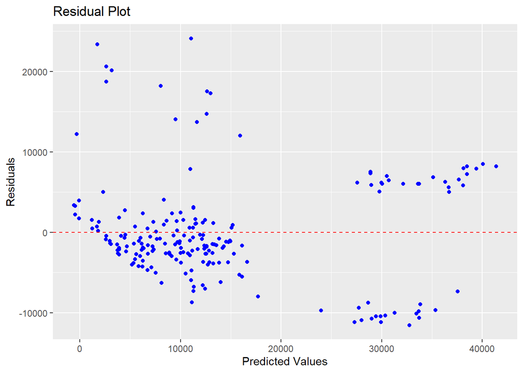

```r
# Calculating residuals
residuals_testA <- test$charges - pred_testA

# Making a data frame with the predicted values and residuals for modA on the test set
residuals_df <- data.frame(Predicted = pred_testA, Residual = residuals_testA)

# Making the residuals scatterplot for modA
ggplot(data = residuals_df, aes(x = Predicted, y = Residual)) +
  geom_point(color = "blue", shape = 16) +
  geom_hline(yintercept = 0, linetype = "dashed", color = "red") +
  labs(title = "Residual Plot", x = "Predicted Values", y = "Residuals")
```

## Conclusion and Improvements

Overall, in the end we fail to reject the null hypothesis that Age, BMI and Children are not significant factors of influence in determining insurance charges. However, two of the variables we had initially hypothesized to be significant factors, did in fact prove to be significant as showcased by the *age* and *bmi* terms in our final model: charges ~ smoker + age + bmi . Hence overall, our final result is that the attributes *smoker*, *age*, and *bmi* have significant influence on determining health care insurance costs.

Given more time though, I would definitely wish to build more variations of the models and compare their R^2 values, confidence intervals, and p-values. I would also start doing the ANOVA tests earlier on in order to have a more thorough analysis in my initial model selections as well. There are many more permutations that are possible with the variables in our data. Each model adds to our understanding of what might produce the best fit. Given the scope and time of this project though, it wasn’t possible to go through all of them. Should I have the time and resources however, I would also wish to gain further background and knowledge around the topic of health insurance costs. Ultimately, a the model needs to be built using our best judgement, and in order to enable that, deep domain knowledge is key for that intrinsic intuition around the subject and to make the most fruitful hypotheses. Finally, in order to gain the most positive benefit from the model, I would seek to test if controlling for factors like smoking or bmi would allow people to decrease their healthcare insurance charges.

## Appendix A - R Code Used

library(mosaic): Loads the mosaic package for statistical modeling and visualization.

library(tidyverse): Loads the tidyverse collection of packages, including ggplot2 and dplyr, for data manipulation and visualization.

library(ggplot2): Loads the ggplot2 package for creating graphics and plots.

library(dplyr): Loads the dplyr package for data manipulation.

library(gridExtra): Loads the gridExtra package, which extends grid graphics capabilities.

library(reshape2): Loads the reshape2 package for reshaping and aggregating data.

require(mosaic): Checks if the mosaic package is available and loads it if necessary.

require(mosaicData): Checks if the mosaicData package is available and loads it if necessary.

read.csv(): Reads a CSV file into a data frame.

set.seed(): Sets the seed for reproducibility in random processes.

sample(): Randomly samples rows from a data frame.

head(): Displays the first few rows of a data frame.

is.na(): Checks for missing values in a data frame.

duplicated(): Checks for duplicated rows in a data frame.

unique(): Removes duplicate rows from a data frame.

nrow(): Returns the number of rows in a data frame.

summary(): Provides a summary of the variables in a data frame.

ggplot(): Initializes a ggplot object.

geom_bar(): Adds a bar layer to a ggplot.

geom_text(): Adds text annotations to a ggplot.

labs(): Adds titles and labels to a ggplot.

grid.arrange(): Arranges multiple ggplot plots in a grid layout.

geom_histogram(): Adds a histogram layer to a ggplot.

geom_boxplot(): Adds a boxplot layer to a ggplot.

as.factor(): Converts a variable to a factor.

cor(): Computes the correlation matrix for selected variables.

melt(): Reshapes a data frame.

scale_fill_gradientn(): Specifies the color gradient for a heatmap.

set.seed(): Sets the seed for reproducibility in random processes.

sample(): Randomly samples indices from a sequence.

nrow(): Returns the number of rows in a data frame.

dim(): Returns the dimensions (number of rows and columns) of an object.

lm(): Fits a linear regression model.

summary(): Provides a summary of the fitted linear regression model.

confint(): Computes confidence intervals for the coefficients of a linear regression model.

predict(): Generates predicted values using a fitted linear regression model.

sqrt(): Computes the square root of a numeric vector.

mean(): Computes the mean of a numeric vector.

data.frame(): Creates a data frame from vectors.

ggplot(): Initializes a ggplot object.

geom_point(): Adds a layer of points to a ggplot.

geom_hline(): Adds a horizontal line to a ggplot.

labs(): Adds titles and labels to a ggplot.

## Appendix B - Data Dictionary

- *age*: age of primary beneficiary; units: years
- *sex*: insurance contractor gender (female/male)
- *bmi*: body mass index, providing an understanding of body, weights that are relatively high or low relative to height, objective index of body weight (kg / m ^ 2) using the ratio of height to weight, ideally 18.5 to 24.9
- *children*: number of children covered by health insurance / Number of dependents; units: children
- *smoker*: smoking (yes/no)
- *region*: the beneficiary’s residential area in the US (northeast/southeast/southwest/northwest)
- *charges*: individual medical costs billed by health insurance; units: USD

## Appendix C - References

1. https://www.kaggle.com/datasets/teertha/ushealthinsurancedataset/data -Last Accessed: December 8, 2023
2. https://www.datacamp.com/tutorial/r-formula-tutorial -Last Accessed: December 8, 2023
3. https://www.geeksforgeeks.org/how-to-shuffle-a-dataframe-in-r-by-rows/ -Last Accessed: December 8, 2023
4. [https://www.tutorialspoint.com/dealing-with-missing-data-in-r#:~:text=Finding Missing Data in R&text=We can use the is,otherwise it should be False](https://www.tutorialspoint.com/dealing-with-missing-data-in-r#:~:text=Finding%20Missing%20Data%20in%20R&text=We%20can%20use%20the%20is,otherwise%20it%20should%20be%20False). -Last Accessed: December 8, 2023
5. https://www.geeksforgeeks.org/identify-and-remove-duplicate-data-in-r/ -Last Accessed: December 8, 2023
6. https://www.datacamp.com/tutorial/linear-regression-R -Last Accessed: December 8, 2023
7. https://r-graph-gallery.com/index.html -Last Accessed: December 8, 2023
8. https://www.geeksforgeeks.org/draw-multiple-ggplot2-plots-side-by-side/ -Last Accessed: December 8, 2023
9. https://www.geeksforgeeks.org/how-to-add-percentage-or-count-labels-above-percentage-bar-plot-in-r/ -Last Accessed: December 8, 2023
10. https://www.datanovia.com/en/blog/how-to-remove-legend-from-a-ggplot/ -Last Accessed: December 8, 2023
11. https://towardsdatascience.com/multi-collinearity-in-regression-fe7a2c1467ea -Last Accessed: December 8, 2023
12. https://www.geeksforgeeks.org/how-to-create-correlation-heatmap-in-r/ -Last Accessed: December 8, 2023
13. https://stackoverflow.com/questions/17200114/how-to-split-data-into-training-testing-sets-using-sample-function -Last Accessed: December 8, 2023
14. https://www.statology.org/train-test-split-r/ -Last Accessed: December 8, 2023
15. https://medium.com/programming-with-r/difference-between-as-numeric-and-as-factor-in-r-1b1c6ff864d2 -Last Accessed: December 8, 2023
16. https://medium.com/@HalderNilimesh/understanding-residual-plots-in-linear-regression-models-a-comprehensive-guide-with-examples-2fb5a60daf26 -Last Accessed: December 8, 2023
17. Kaplan, D. (2013). Statistical modeling: A fresh approach. Verlag nicht ermittelbar. -Last Accessed: December 8, 2023